# Learning Analytics Investigation: FutureLearn MOOC

Student Name

2026-01-12

# 1 Introduction

Learning analytics is an attempt to learn about the online learning materials by relying on the data. The report examines the learner interactions patterns in a massive open online course with FutureLearn with reproducible data science tools. The study can examine step-level interaction data of several courses run to determine what components of a course receive the most and least engagement. The study is based on the CRISP-DM framework and uses exploratory analysis, clustering, and predictive modelling to produce insights that can be applied to make evidence-based changes in course design and learner experience.

# 2 Business Understanding

The FutureLearn course provider is the stakeholder in this investigation. The main goal is to learn the patterns of engagement of learners with individual course steps so that the course design and retention could be improved. The identification of steps that produce high or low amounts of interaction allows prioritisation of high-impact work as well as possible redesign of less effective work. The definition of success includes having a clear definition of engagement patterns that can be used to make evidence-based decisions to improve the course efficacy and the experiences of learners.

# 3 Data Understanding

The interaction data analyzed in this investigation was gathered as raw interaction data of seven runs of an online FutureLearn massive open course. The observation is a learner engagement with a particular course step, and this means that there will be many records per learner throughout the course. The data set has variables in which identifiers of steps and number of interactions are explained. The preliminary investigation generates the existence of missing values in certain fields, combined with a considerable deviation in the frequency of interaction between steps. These features represent natural learners’ behaviour and need proper treatment when preparing data.

## 3.1 R Markdown

```r
library(ggplot2)
library(skimr)
library(caret)
```

# 4 Data Preparation

The industry characteristic represented in this is the programmatic loading of FutureLearn raw future step-activity data. A tidyverse is used in order to identify multiple CSV files and read and merge them into one dataset. The data is stored as a cache to assure efficient reuse and reproducibility without the need of manual loading of data.

The data cleaning that was employed on data step activity. All records containing no step identifiers are deleted and the step variables standardised to an identical type of data. The cleaned data is persisted to be in a form of downstream processing in addition to providing an easy to understand and reproducible preprocessing phase.

Data summary

| Name | step_activity_clean |
| --- | --- |
| Number of rows | 423072 |
| Number of columns | 7 |
| _______________________ |  |
| Column type frequency: |  |
| character | 5 |
| numeric | 2 |
| ________________________ |  |
| Group variables | None |

**Variable type: character**

| skim_variable | n_missing | complete_rate | min | max | empty | n_unique | whitespace |
| --- | --- | --- | --- | --- | --- | --- | --- |
| source_file | 0 | 1.00 | 34 | 34 | 0 | 7 | 0 |
| learner_id | 0 | 1.00 | 36 | 36 | 0 | 20285 | 0 |
| step | 0 | 1.00 | 3 | 4 | 0 | 58 | 0 |
| first_visited_at | 0 | 1.00 | 23 | 23 | 0 | 412828 | 0 |
| last_completed_at | 37514 | 0.91 | 23 | 23 | 0 | 377141 | 0 |

**Variable type: numeric**

| skim_variable | n_missing | complete_rate | mean | sd | p0 | p25 | p50 | p75 | p100 | hist |
| --- | --- | --- | --- | --- | --- | --- | --- | --- | --- | --- |
| week_number | 0 | 1 | 1.76 | 0.80 | 1 | 1 | 2 | 2 | 3 | ▇▁▆▁▃ |
| step_number | 0 | 1 | 9.72 | 6.05 | 1 | 4 | 9 | 15 | 23 | ▇▅▆▅▂ |

# 5 Descriptive Analysis

```
## # A tibble: 6 × 2
##   step      n
##   <chr> <int>
## 1 1.1   29081
## 2 1.2   15312
## 3 1.3   14246
## 4 1.4   12927
## 5 2.1   12733
## 6 2.2   12173
```

```
##    Min. 1st Qu.  Median    Mean 3rd Qu.    Max.
##    2265    4925    5776    7294    8728   29081
```

This figure presents an organized description of the cleaned step activity dataset obtained with the skimr package. It emphasises the variable completeness level, the counts of unique values, and missing data patterns, which provides an overview of the data quality level and helps to make informed decisions on further analytical measures.

This report of descriptive statistics of the interactions of learners with course steps, such as central tendency and dispersion measures. These findings demonstrate that the distribution is right-skewed with a few steps getting considerably more interaction, which further encourages additional exploratory and clustering analyses.

# 6 Exploratory Visualisation

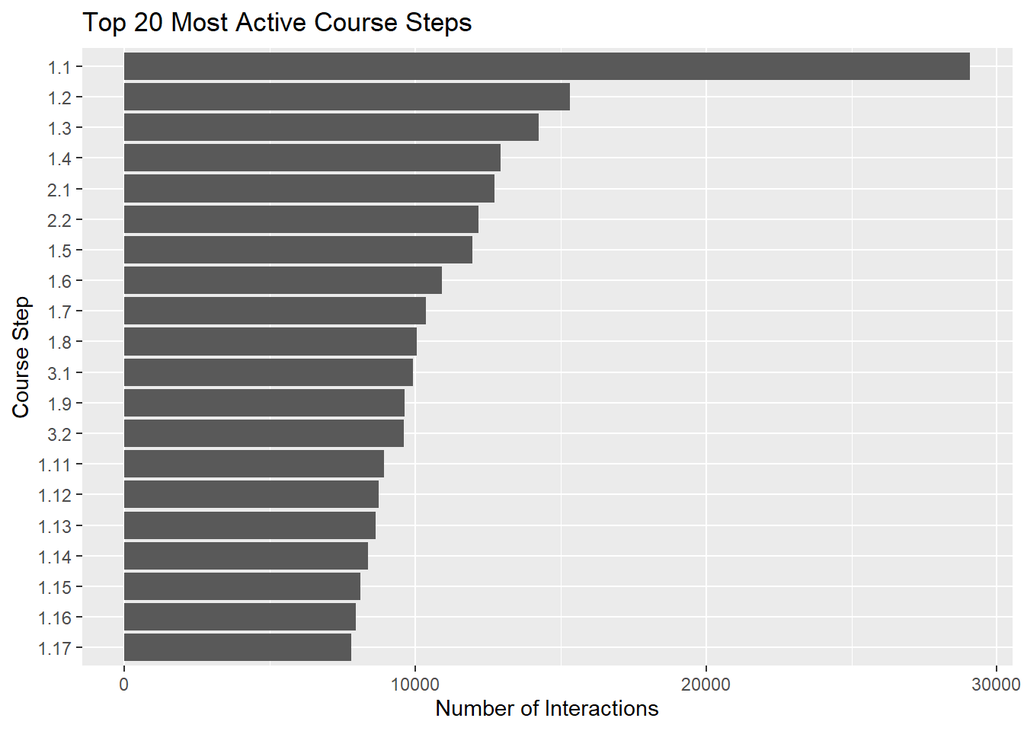

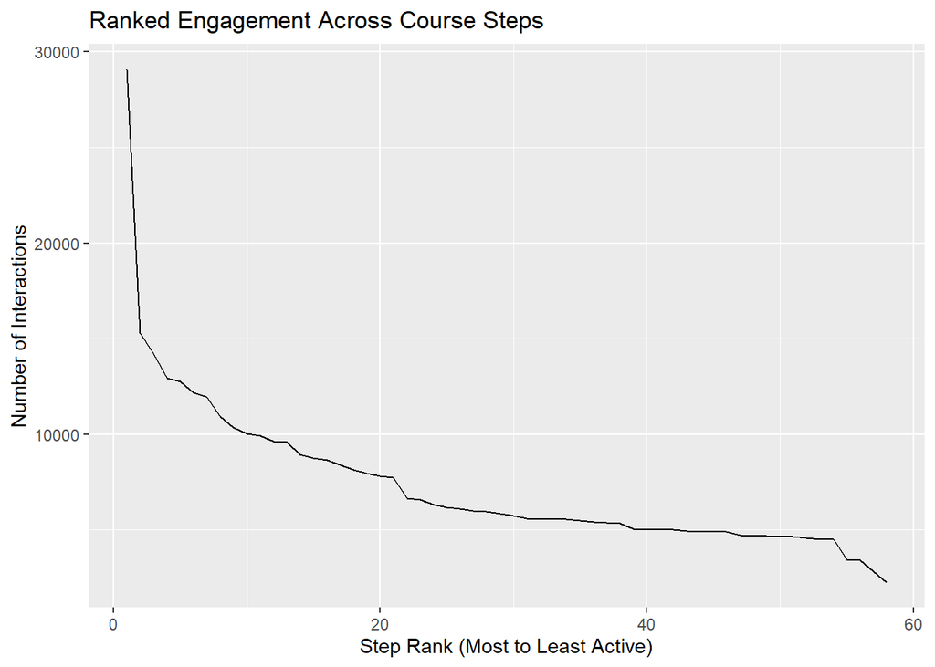

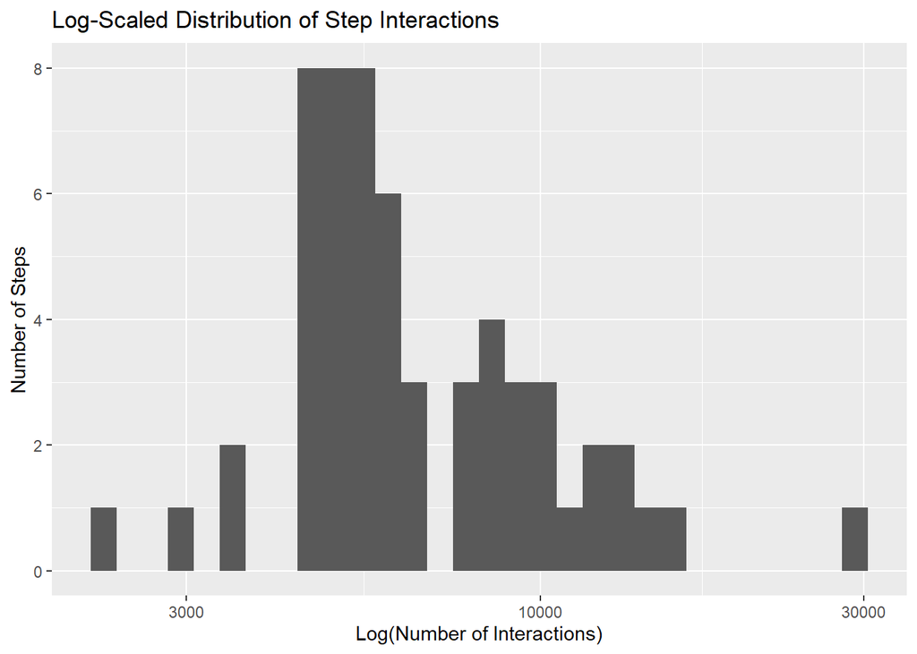

This character shows the twenty course steps that have the greatest amount of learner interactions per course run. This figure can assist the course provider in determining where the learners focus their time and energy by noting the steps that are predominant by the learners. This understanding can be applied to decisions regarding what steps to keep, improve, or take as templates to redesign less engaging content. It can also be helpful in ranking instructional resources by identifying steps that make the most significant contribution to engagement of learners and course value.

This number facilitates ordering of all steps of the course with the most active on one end and the least active on the other end. The sharp upward decline, with a long tail, shows that there is a great deal of concentration in very few steps and many steps are actually connected with far fewer interactions. This value aids in checking the fact that the engagement of learners is not evenly distributed and allows one to identify the core of steps that rule out engagement. This understanding is important to the stakeholder, as it shows possible places of bottleneck or dissociation in the course structure to make specific interventions to enhance continuity and keep them engaged throughout subsequent steps.

This figure shows a log-scale distribution of the counts of step interactions and this scale enables easier visualisation of massively skewed engagement data. Log transformation will diminish the effect of the extreme outliers and bring out the underlying patterns that are not visible. This number can be used to illustrate that the predominance of steps is at the lower engagement rates, whereas few steps handle extremely high volumes of interactions. This skew should be noted because suitable methods of analysis could be clustering or non-linear models.